# Relatório do Trabalho 1° de Mineração de Dados

### Alunos

- `Natanael Moreira de Lemos` - Matricula: `398447`
- `Ramiro Campos de Castro` - Matricula: `400723` ## Os datasets utilizados neste filme foram extraídos de: ### 1. https://www.kaggle.com/ruchi798/movies-on-netflix-prime-video-hulu-and-disney/data# ### 2. https://www.kaggle.com/ruchi798/tv-shows-on-netflix-prime-video-hulu-and-disney

## Eles contém inforamções sobre filmes(1) e séries(2) encontradas nas plataformas Netflix, Prime Video, Hulu e Disney+

### OBS: o relatório e arquivos necessários também se encontram em: https://github.com/Natan10/mineracao-dados-ufc

# 1. Importando as Bibliotecas, lendo os DataSets

```python
import numpy as np
import pandas as pd
import seaborn as sns
import sidetable
import plotly.express as px
import requests
from bs4 import BeautifulSoup

import matplotlib.pyplot as plt
%matplotlib inline
```

```python
df_movies = pd.read_csv("MoviesOnStreamingPlatforms_updated.csv")
df_series = pd.read_csv("tv_shows.csv")
```

# 2. Vendo informações sobre os DataSets

```python
df_movies
```

|  | Unnamed: 0 | ID | Title | Year | Age | IMDb | Rotten Tomatoes | Netflix | Hulu | Prime Video | Disney+ | Type | Directors | Genres | Country | Language | Runtime |
| --- | --- | --- | --- | --- | --- | --- | --- | --- | --- | --- | --- | --- | --- | --- | --- | --- | --- |
| 0 | 0 | 1 | Inception | 2010 | 13+ | 8.8 | 87% | 1 | 0 | 0 | 0 | 0 | Christopher Nolan | Action,Adventure,Sci-Fi,Thriller | United States,United Kingdom | English,Japanese,French | 148.0 |
| 1 | 1 | 2 | The Matrix | 1999 | 18+ | 8.7 | 87% | 1 | 0 | 0 | 0 | 0 | Lana Wachowski,Lilly Wachowski | Action,Sci-Fi | United States | English | 136.0 |
| 2 | 2 | 3 | Avengers: Infinity War | 2018 | 13+ | 8.5 | 84% | 1 | 0 | 0 | 0 | 0 | Anthony Russo,Joe Russo | Action,Adventure,Sci-Fi | United States | English | 149.0 |
| 3 | 3 | 4 | Back to the Future | 1985 | 7+ | 8.5 | 96% | 1 | 0 | 0 | 0 | 0 | Robert Zemeckis | Adventure,Comedy,Sci-Fi | United States | English | 116.0 |
| 4 | 4 | 5 | The Good, the Bad and the Ugly | 1966 | 18+ | 8.8 | 97% | 1 | 0 | 1 | 0 | 0 | Sergio Leone | Western | Italy,Spain,West Germany | Italian | 161.0 |
| ... | ... | ... | ... | ... | ... | ... | ... | ... | ... | ... | ... | ... | ... | ... | ... | ... | ... |
| 16739 | 16739 | 16740 | The Ghosts of Buxley Hall | 1980 | NaN | 6.2 | NaN | 0 | 0 | 0 | 1 | 0 | Bruce Bilson | Comedy,Family,Fantasy,Horror | United States | English | 120.0 |
| 16740 | 16740 | 16741 | The Poof Point | 2001 | 7+ | 4.7 | NaN | 0 | 0 | 0 | 1 | 0 | Neal Israel | Comedy,Family,Sci-Fi | United States | English | 90.0 |
| 16741 | 16741 | 16742 | Sharks of Lost Island | 2013 | NaN | 5.7 | NaN | 0 | 0 | 0 | 1 | 0 | Neil Gelinas | Documentary | United States | English | NaN |
| 16742 | 16742 | 16743 | Man Among Cheetahs | 2017 | NaN | 6.6 | NaN | 0 | 0 | 0 | 1 | 0 | Richard Slater-Jones | Documentary | United States | English | NaN |
| 16743 | 16743 | 16744 | In Beaver Valley | 1950 | NaN | NaN | NaN | 0 | 0 | 0 | 1 | 0 | James Algar | Documentary,Short,Family | United States | English | 32.0 |

16744 rows × 17 columns

```python
df_movies.info()
```

```
<class 'pandas.core.frame.DataFrame'>
RangeIndex: 16744 entries, 0 to 16743
Data columns (total 17 columns):
 #   Column           Non-Null Count  Dtype
---  ------           --------------  -----
 0   Unnamed: 0       16744 non-null  int64
 1   ID               16744 non-null  int64
 2   Title            16744 non-null  object
 3   Year             16744 non-null  int64
 4   Age              7354 non-null   object
 5   IMDb             16173 non-null  float64
 6   Rotten Tomatoes  5158 non-null   object
 7   Netflix          16744 non-null  int64
 8   Hulu             16744 non-null  int64
 9   Prime Video      16744 non-null  int64
 10  Disney+          16744 non-null  int64
 11  Type             16744 non-null  int64
 12  Directors        16018 non-null  object
 13  Genres           16469 non-null  object
 14  Country          16309 non-null  object
 15  Language         16145 non-null  object
 16  Runtime          16152 non-null  float64
dtypes: float64(2), int64(8), object(7)
memory usage: 2.2+ MB
```

## O dataset de Filmes contém 16744 elementos, com 17 atributos cada, além de possuir vários daods faltantes, como visto em 'df_movies.info()'.

A coluna `Country` indica os países onde o filme foi gravado, e o `Type` indica se é um filme(0) ou uma série(1).

```python
df_series
```

|  | Unnamed: 0 | Title | Year | Age | IMDb | Rotten Tomatoes | Netflix | Hulu | Prime Video | Disney+ | type |
| --- | --- | --- | --- | --- | --- | --- | --- | --- | --- | --- | --- |
| 0 | 0 | Breaking Bad | 2008 | 18+ | 9.5 | 96% | 1 | 0 | 0 | 0 | 1 |
| 1 | 1 | Stranger Things | 2016 | 16+ | 8.8 | 93% | 1 | 0 | 0 | 0 | 1 |
| 2 | 2 | Money Heist | 2017 | 18+ | 8.4 | 91% | 1 | 0 | 0 | 0 | 1 |
| 3 | 3 | Sherlock | 2010 | 16+ | 9.1 | 78% | 1 | 0 | 0 | 0 | 1 |
| 4 | 4 | Better Call Saul | 2015 | 18+ | 8.7 | 97% | 1 | 0 | 0 | 0 | 1 |
| ... | ... | ... | ... | ... | ... | ... | ... | ... | ... | ... | ... |
| 5606 | 5606 | Tut's Treasures: Hidden Secrets | 2018 | NaN | NaN | NaN | 0 | 0 | 0 | 1 | 1 |
| 5607 | 5607 | Paradise Islands | 2017 | NaN | NaN | NaN | 0 | 0 | 0 | 1 | 1 |
| 5608 | 5608 | Wild Russia | 2018 | NaN | NaN | NaN | 0 | 0 | 0 | 1 | 1 |
| 5609 | 5609 | Love & Vets | 2017 | NaN | NaN | NaN | 0 | 0 | 0 | 1 | 1 |
| 5610 | 5610 | United States of Animals | 2016 | NaN | NaN | NaN | 0 | 0 | 0 | 1 | 1 |

5611 rows × 11 columns

```python
df_series.info()
```

```
<class 'pandas.core.frame.DataFrame'>
RangeIndex: 5611 entries, 0 to 5610
Data columns (total 11 columns):
 #   Column           Non-Null Count  Dtype
---  ------           --------------  -----
 0   Unnamed: 0       5611 non-null   int64
 1   Title            5611 non-null   object
 2   Year             5611 non-null   int64
 3   Age              3165 non-null   object
 4   IMDb             4450 non-null   float64
 5   Rotten Tomatoes  1011 non-null   object
 6   Netflix          5611 non-null   int64
 7   Hulu             5611 non-null   int64
 8   Prime Video      5611 non-null   int64
 9   Disney+          5611 non-null   int64
 10  type             5611 non-null   int64
dtypes: float64(1), int64(7), object(3)
memory usage: 482.3+ KB
```

## Tendo visto os dois datasets, percebe-se que a coluna 'Unnamed: 0' é uma coluna equivalente aos índices do DataFrame, então pode-se excluí-la sem nenuhma perda.

## E considerando que 'IMDb' e 'Rotten Tomatoes' tem o mesmo intuito, o de avaliar a qualidade da obra, e em ambos os dataset a quantidade de dados faltantes referentes a coluna 'Rotten Tomatoes' é superior a 50%, irá ser considerada apenas a avaliação do 'IMDb' para a maioria dos casos.

# 3. Pré-Processando os datasets

Limpando a coluna `Age` para que ela possua apenas números, e a coluna `Rotten Tomatoes`, para que fica similar a `Age`

```python
## Limpeza na coluna de idade, removendo o '+'

for i in range(len(df_movies['Age'])):
    aux = df_movies.loc[i,'Age']
    if aux != np.nan or aux != 'all' or aux != '':
        aux = str(aux)
        if '+' in aux:
            df_movies.loc[i,'Age'] = aux.strip().split('+')[0]


for i in range(len(df_series['Age'])):
    aux = df_series.loc[i,'Age']
    if aux != np.nan or aux != 'all' or aux != '':
        aux = str(aux)
        if '+' in aux:
            df_series.loc[i,'Age'] = aux.strip().split('+')[0]
```

```python
## Limpeza na coluna do Rotten Tomatoes no Filmes

for i in range(len(df_movies['Rotten Tomatoes'])):
        aux = df_movies.loc[i,'Rotten Tomatoes']
        if aux != np.nan or aux != '':
            aux = str(aux)
            if '%' in aux:
                df_movies.loc[i,'Rotten Tomatoes'] = aux.strip().split('%')[0]

for i in range(len(df_series['Rotten Tomatoes'])):
        aux = df_series.loc[i,'Rotten Tomatoes']
        if aux != np.nan or aux != '':
            aux = str(aux)
            if '%' in aux:
                df_series.loc[i,'Rotten Tomatoes'] = aux.strip().split('%')[0]

## Deixa os valores como floats de 0 a 10, assim como o IMDb
df_movies['Rotten Tomatoes'] = df_movies['Rotten Tomatoes'].apply(lambda x: float(x)/10)
df_series['Rotten Tomatoes'] = df_series['Rotten Tomatoes'].apply(lambda x: float(x)/10)
```

```python
df_movies.head(5)
```

|  | Unnamed: 0 | ID | Title | Year | Age | IMDb | Rotten Tomatoes | Netflix | Hulu | Prime Video | Disney+ | Type | Directors | Genres | Country | Language | Runtime |
| --- | --- | --- | --- | --- | --- | --- | --- | --- | --- | --- | --- | --- | --- | --- | --- | --- | --- |
| 0 | 0 | 1 | Inception | 2010 | 13 | 8.8 | 8.7 | 1 | 0 | 0 | 0 | 0 | Christopher Nolan | Action,Adventure,Sci-Fi,Thriller | United States,United Kingdom | English,Japanese,French | 148.0 |
| 1 | 1 | 2 | The Matrix | 1999 | 18 | 8.7 | 8.7 | 1 | 0 | 0 | 0 | 0 | Lana Wachowski,Lilly Wachowski | Action,Sci-Fi | United States | English | 136.0 |
| 2 | 2 | 3 | Avengers: Infinity War | 2018 | 13 | 8.5 | 8.4 | 1 | 0 | 0 | 0 | 0 | Anthony Russo,Joe Russo | Action,Adventure,Sci-Fi | United States | English | 149.0 |
| 3 | 3 | 4 | Back to the Future | 1985 | 7 | 8.5 | 9.6 | 1 | 0 | 0 | 0 | 0 | Robert Zemeckis | Adventure,Comedy,Sci-Fi | United States | English | 116.0 |
| 4 | 4 | 5 | The Good, the Bad and the Ugly | 1966 | 18 | 8.8 | 9.7 | 1 | 0 | 1 | 0 | 0 | Sergio Leone | Western | Italy,Spain,West Germany | Italian | 161.0 |

```python
df_series.head(5)
```

|  | Unnamed: 0 | Title | Year | Age | IMDb | Rotten Tomatoes | Netflix | Hulu | Prime Video | Disney+ | type |
| --- | --- | --- | --- | --- | --- | --- | --- | --- | --- | --- | --- |
| 0 | 0 | Breaking Bad | 2008 | 18 | 9.5 | 9.6 | 1 | 0 | 0 | 0 | 1 |
| 1 | 1 | Stranger Things | 2016 | 16 | 8.8 | 9.3 | 1 | 0 | 0 | 0 | 1 |
| 2 | 2 | Money Heist | 2017 | 18 | 8.4 | 9.1 | 1 | 0 | 0 | 0 | 1 |
| 3 | 3 | Sherlock | 2010 | 16 | 9.1 | 7.8 | 1 | 0 | 0 | 0 | 1 |
| 4 | 4 | Better Call Saul | 2015 | 18 | 8.7 | 9.7 | 1 | 0 | 0 | 0 | 1 |

### A coluna 'type' no dataset de series está com nomeação diferente , então tem-se de modificar seu nome para 'Type', para ficar igual nos dois datasets.

### E renomear a coluna 'Unnamed: 0' do df_series para 'ID', para ambos os dataframes ficarem com a uma coluna nomeada ID.

```python
df_series.rename(columns={'Unnamed: 0': 'ID', 'type': 'Type'},inplace=True)
```

### Por fim, ajeitar o ID das séries para ficar começar a partir do último ID dos filmes, e assim não haver IDs repetidos

```python
numMovies = len(df_movies.index)
df_series['ID']=df_series.apply(lambda x: x['ID']+numMovies+1,axis=1)
```

# 4. Criando datasets extras

Para facilitar o acesso a alguns dados criamos alguns datasets auxiliares 2 deles demoram muito para serem criados, então foi um arquivo .csv deles. Entretanto seus códigos estão logo abaixo, comentados, para caso necessite ser executado.

# 4.1. Dataset com séries e filmes, e suas colunas em comuns

```python
colunas = []

for col in df_series.columns:
    colunas.append(col)
print("Colunas em comum dos 2 DataSets:\n",colunas)
df_streaming = pd.concat([df_movies[colunas],df_series], axis=0)
df_streaming.reset_index(drop=True, inplace=True) # para que o índice fique normalizado
# df_streaming é o data frame com todos as séries e filmes
```

```
Colunas em comum dos 2 DataSets:
 ['ID', 'Title', 'Year', 'Age', 'IMDb', 'Rotten Tomatoes', 'Netflix', 'Hulu', 'Prime Video', 'Disney+', 'Type']
```

```python
df_streaming
```

|  | ID | Title | Year | Age | IMDb | Rotten Tomatoes | Netflix | Hulu | Prime Video | Disney+ | Type |
| --- | --- | --- | --- | --- | --- | --- | --- | --- | --- | --- | --- |
| 0 | 1 | Inception | 2010 | 13 | 8.8 | 8.7 | 1 | 0 | 0 | 0 | 0 |
| 1 | 2 | The Matrix | 1999 | 18 | 8.7 | 8.7 | 1 | 0 | 0 | 0 | 0 |
| 2 | 3 | Avengers: Infinity War | 2018 | 13 | 8.5 | 8.4 | 1 | 0 | 0 | 0 | 0 |
| 3 | 4 | Back to the Future | 1985 | 7 | 8.5 | 9.6 | 1 | 0 | 0 | 0 | 0 |
| 4 | 5 | The Good, the Bad and the Ugly | 1966 | 18 | 8.8 | 9.7 | 1 | 0 | 1 | 0 | 0 |
| ... | ... | ... | ... | ... | ... | ... | ... | ... | ... | ... | ... |
| 22350 | 22351 | Tut's Treasures: Hidden Secrets | 2018 | NaN | NaN | NaN | 0 | 0 | 0 | 1 | 1 |
| 22351 | 22352 | Paradise Islands | 2017 | NaN | NaN | NaN | 0 | 0 | 0 | 1 | 1 |
| 22352 | 22353 | Wild Russia | 2018 | NaN | NaN | NaN | 0 | 0 | 0 | 1 | 1 |
| 22353 | 22354 | Love & Vets | 2017 | NaN | NaN | NaN | 0 | 0 | 0 | 1 | 1 |
| 22354 | 22355 | United States of Animals | 2016 | NaN | NaN | NaN | 0 | 0 | 0 | 1 | 1 |

22355 rows × 11 columns

# 4.2. Dataset com os países onde os filmes foram filmados

- o código abaixo é usado para gerar o dataset Country.csv, porém demora mais 5min para executá-lo

```python
listCountries = []
for i in df_movies["Country"].astype('category'):
    if(type(i) == float):
        continue
    # traverse for all elements
    for x in i.split(","):
        # check if exists in unique_list or not
        if x not in listCountries:
            listCountries.append(x)
listCountries.sort()
# colunasCountries = ["ID", "IMDb","Rotten Tomatoes"]
# for p in listCountries:
#     colunasCountries.append(p)


# df_countries = pd.DataFrame(columns=colunasCountries)
# for i in df_movies["Country"].astype('category'):
#     row =  { i : [0] for i in colunasCountries }
#     row["ID"] = num+1
#     row["IMDb"] = df_movies.iloc[num,5]
#     row["Rotten Tomatoes"] = df_movies.iloc[num,6]
#     if(type(i) == float):
#         # nesse caso, o(s) pais(es) onde os filmes foram filmados não está(ão) listado(s)
#         None
#     else:
#         for x in i.split(","):
#                 row[x] = 1

#     row = pd.DataFrame(data=row)
#     df_countries = df = pd.concat([df_countries, row])
# df_countries.reset_index(drop=True, inplace=True)
# df_countries.to_csv('Countries.csv',index=False)
```

```python
df_countries = pd.read_csv("Countries.csv")
df_countries.head(5)
```

|  | ID | IMDb | Rotten Tomatoes | Afghanistan | Albania | Algeria | Angola | Argentina | Armenia | Aruba | ... | United States | Uruguay | Vanuatu | Venezuela | Vietnam | West Germany | Yemen | Yugoslavia | Zambia | Zimbabwe |
| --- | --- | --- | --- | --- | --- | --- | --- | --- | --- | --- | --- | --- | --- | --- | --- | --- | --- | --- | --- | --- | --- |
| 0 | 1 | 8.8 | 8.7 | 0 | 0 | 0 | 0 | 0 | 0 | 0 | ... | 1 | 0 | 0 | 0 | 0 | 0 | 0 | 0 | 0 | 0 |
| 1 | 2 | 8.7 | 8.7 | 0 | 0 | 0 | 0 | 0 | 0 | 0 | ... | 1 | 0 | 0 | 0 | 0 | 0 | 0 | 0 | 0 | 0 |
| 2 | 3 | 8.5 | 8.4 | 0 | 0 | 0 | 0 | 0 | 0 | 0 | ... | 1 | 0 | 0 | 0 | 0 | 0 | 0 | 0 | 0 | 0 |
| 3 | 4 | 8.5 | 9.6 | 0 | 0 | 0 | 0 | 0 | 0 | 0 | ... | 1 | 0 | 0 | 0 | 0 | 0 | 0 | 0 | 0 | 0 |
| 4 | 5 | 8.8 | 9.7 | 0 | 0 | 0 | 0 | 0 | 0 | 0 | ... | 0 | 0 | 0 | 0 | 0 | 1 | 0 | 0 | 0 | 0 |

5 rows × 171 columns

# 4.3. Dataset com os gêneros dos filmes

- o código abaixo é usado para gerar o dataset Genres.csv, porém demora mais de 5min para executá-lo

```python
# listGenres = []
# for i in df_movies["Genres"].astype('category'):
#     if(type(i) == float):
#         continue
#     # traverse for all elements
#     for x in i.split(","):
#         # check if exists in unique_list or not
#         if x not in listGenres:
#             listGenres.append(x)
# listGenres.sort()
# colunasGenres = ["ID", "IMDb","Rotten Tomatoes"]
# for p in listGenres:
#     colunasG.append(p)


# df_genres = pd.DataFrame(columns=colunasGenres)
# for i in df_movies["Genres"].astype('category'):
#     row =  { i : [0] for i in colunasGenres }
#     row["ID"] = num+1
#     row["IMDb"] = df_movies.iloc[num,5]
#     row["Rotten Tomatoes"] = df_movies.iloc[num,6]

#     if(type(i) == float):
#         # nesse caso, o(s) pais(es) onde os filmes foram filmados não está(ão) listado(s)
#         row[x] = np.nan
#     else:
#         for x in i.split(","):
#                 row[x] = 1

#     row = pd.DataFrame(data=row)
#     df_genres = df = pd.concat([df_genres, row])
# df_genres.reset_index(drop=True, inplace=True)
# df_genres.to_csv('Genres.csv',index=False)
```

```python
df_genres = pd.read_csv("Genres.csv")
df_genres.head(5)
```

|  | ID | IMDb | Rotten Tomatoes | Action | Adventure | Animation | Biography | Comedy | Crime | Documentary | ... | News | Reality-TV | Romance | Sci-Fi | Short | Sport | Talk-Show | Thriller | War | Western |
| --- | --- | --- | --- | --- | --- | --- | --- | --- | --- | --- | --- | --- | --- | --- | --- | --- | --- | --- | --- | --- | --- |
| 0 | 1 | 8.8 | 87% | 1 | 1 | 0 | 0 | 0 | 0 | 0 | ... | 0 | 0 | 0 | 1 | 0 | 0 | 0 | 1 | 0 | 0 |
| 1 | 2 | 8.7 | 87% | 1 | 0 | 0 | 0 | 0 | 0 | 0 | ... | 0 | 0 | 0 | 1 | 0 | 0 | 0 | 0 | 0 | 0 |
| 2 | 3 | 8.5 | 84% | 1 | 1 | 0 | 0 | 0 | 0 | 0 | ... | 0 | 0 | 0 | 1 | 0 | 0 | 0 | 0 | 0 | 0 |
| 3 | 4 | 8.5 | 96% | 0 | 1 | 0 | 0 | 1 | 0 | 0 | ... | 0 | 0 | 0 | 1 | 0 | 0 | 0 | 0 | 0 | 0 |
| 4 | 5 | 8.8 | 97% | 0 | 0 | 0 | 0 | 0 | 0 | 0 | ... | 0 | 0 | 0 | 0 | 0 | 0 | 0 | 0 | 0 | 1 |

5 rows × 30 columns

# 4.4. Dataset com a Língua dos filmes

```python
listLanguage = []
notDef = 0
for i in df_movies["Language"].astype('category'):
    if(type(i) == float):
        notDef += 1
        continue
    # traverse for all elements
    for x in i.split(","):
        # check if exists in unique_list or not
        if x not in listLanguage:
            listLanguage.append(x)
listLanguage.sort()
# colunasLanguage = ["ID"]
# for l in listLanguage:
#     colunasLanguage.append(l)

# languages = pd.DataFrame(columns=colunasLanguage)
# for i in df_movies["Language"].astype('category'):
#     print("Linha de número %d"%(num+1))
#     row =  { i : [0] for i in colunasLanguage }
#     row["ID"] = num+1

#     if(type(i) == float):
#         # nesse caso, o(s) pais(es) onde os filmes foram filmados não está(ão) listado(s)
#         None
#     else:
#         for x in i.split(","):
#                 row[x] = 1

#     row = pd.DataFrame(data=row)
#     languages = df = pd.concat([languages, row])
# df_languages.reset_index(drop=True, inplace=True)
# df_languages.to_csv('Languages.csv',index=False)
```

```python
df_languages = pd.read_csv("Languages.csv")
df_languages.head(5)
```

|  | ID | Ancient (to 1453) | Aboriginal | Acholi | Afrikaans | Akan | Albanian | Algonquin | American Sign Language | Amharic | ... | Uighur | Ukrainian | Urdu | Vietnamese | Welsh | Wolof | Xhosa | Yiddish | Yoruba | Zulu |
| --- | --- | --- | --- | --- | --- | --- | --- | --- | --- | --- | --- | --- | --- | --- | --- | --- | --- | --- | --- | --- | --- |
| 0 | 1 | 0 | 0 | 0 | 0 | 0 | 0 | 0 | 0 | 0 | ... | 0 | 0 | 0 | 0 | 0 | 0 | 0 | 0 | 0 | 0 |
| 1 | 2 | 0 | 0 | 0 | 0 | 0 | 0 | 0 | 0 | 0 | ... | 0 | 0 | 0 | 0 | 0 | 0 | 0 | 0 | 0 | 0 |
| 2 | 3 | 0 | 0 | 0 | 0 | 0 | 0 | 0 | 0 | 0 | ... | 0 | 0 | 0 | 0 | 0 | 0 | 0 | 0 | 0 | 0 |
| 3 | 4 | 0 | 0 | 0 | 0 | 0 | 0 | 0 | 0 | 0 | ... | 0 | 0 | 0 | 0 | 0 | 0 | 0 | 0 | 0 | 0 |
| 4 | 5 | 0 | 0 | 0 | 0 | 0 | 0 | 0 | 0 | 0 | ... | 0 | 0 | 0 | 0 | 0 | 0 | 0 | 0 | 0 | 0 |

5 rows × 179 columns

# 5. Explorando os dados presentes

# 5.1. Análise comparativa das Plataforma

Primeiramente separando os títulos(séries e filmes) de cada plataforma

```python
# Filmes
df_prime_movies = df_movies[df_movies['Prime Video'] == 1].iloc[:,[1,2,3,4,5,6,7,11,12,13,14,15,16]]
df_netflix_movies = df_movies[df_movies['Netflix'] == 1].iloc[:,[1,2,3,4,5,6,8,11,12,13,14,15,16]]
df_hulu_movies = df_movies[df_movies['Hulu'] == 1].iloc[:,[1,2,3,4,5,6,7,9,12,13,14,15,16]]
df_disney_movies = df_movies[df_movies['Disney+'] == 1].iloc[:,[1,2,3,4,5,6,10,11,12,13,14,15,16]]

# Séries
df_prime_series = df_series[df_series['Prime Video'] == 1].iloc[:,[1,2,3,4,5]]
df_netflix_series = df_series[df_series['Netflix'] == 1].iloc[:,[1,2,3,4,5]]
df_hulu_series = df_series[df_series['Hulu'] == 1].iloc[:,[1,2,3,4,5]]
df_disney_series = df_series[df_series['Disney+'] == 1].iloc[:,[1,2,3,4,5]]
```

### 5.1.1. A Porcentagem de Filmes e Séries de cada Plataforma em relação ao total de títulos presentes em todas

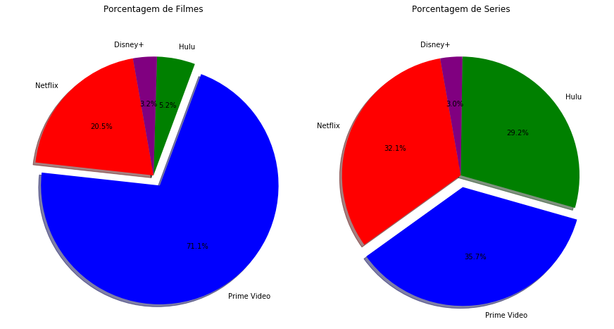

```python
labels = ['Netflix','Prime Video', 'Hulu','Disney+']
total = df_streaming.sum(axis=0)[5:10]
num_plat_movies = df_streaming[df_streaming['Type']==0].sum(axis=0)[5:10]
num_plat_series = df_streaming[df_streaming['Type']==1].sum(axis=0)[5:10]

sizes_movies = list(num_plat_movies[labels])


sizes_series = list(num_plat_series[labels])


fig,axes = plt.subplots(nrows = 1,ncols = 2,figsize=(12,7),constrained_layout=True)
explode = (0, 0.1, 0, 0)

axes[0].pie(sizes_movies, explode=explode, labels=labels, autopct='%1.1f%%',shadow=True, startangle=100, colors = ['red','blue','green', 'purple'])
axes[0].set_title('Porcentagem de Filmes\n')

axes[1].pie(sizes_series, explode=explode, labels=labels, autopct='%1.1f%%',shadow=True, startangle=100, colors = ['red','blue','green', 'purple'])
axes[1].set_title('Porcentagem de Series\n')
plt.show()
```

### 5.1.2. Porcentagem de Filmes e Séries em relação ao total de títulos

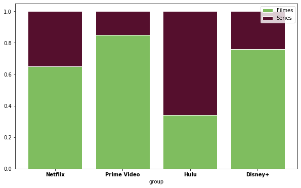

```python
percent_movies = num_plat_movies[labels]/total[labels]
percent_movies = percent_movies.apply(lambda x: round(x,2))

percent_serie = num_plat_series[labels]/total[labels]
percent_serie = percent_serie.apply(lambda x: round(x,2))

p = [0,1,2,3] # posição das barras

barWidth = 0.8
plt.figure(figsize=(10,6))
plt.bar(p, percent_movies, color='#7fbd5f', edgecolor='white', width=barWidth, label= 'Filmes')

plt.bar(p, percent_serie, bottom=percent_movies, color='#550f2d', edgecolor='white', width=barWidth, label= 'Series')


# Custom X axis
plt.xticks(p, labels, fontweight='bold')
plt.xlabel("group")

# Show graphic
plt.legend()
plt.show()
```

### 5.1.3. Idade Recomendada dos Títulos por Plataforma

```python
order = ['7','13','16','18','all'] # ordem das idades
```

- Filmes

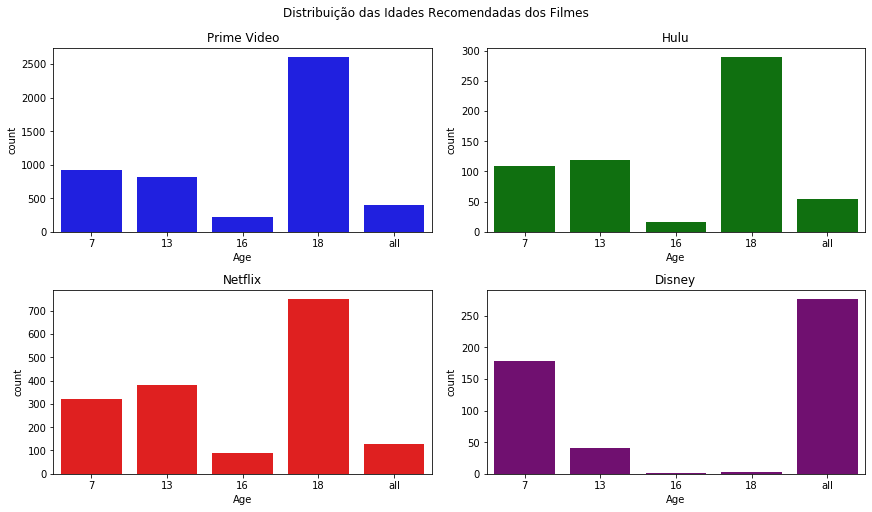

```python
fig,axs = plt.subplots(nrows = 2,ncols = 2,figsize=(12,7),constrained_layout=True)
fig.suptitle('Distribuição das Idades Recomendadas dos Filmes')
sns.countplot(x='Age',data=df_prime_movies,ax=axs[0][0],order=order, color = 'blue')
axs[0][0].set_title('Prime Video')

sns.countplot(x='Age',data=df_hulu_movies,ax=axs[0][1],order=order, color = 'green')
axs[0][1].set_title('Hulu')

sns.countplot(x='Age',data=df_netflix_movies,ax=axs[1][0],order=order, color = 'red')
axs[1][0].set_title('Netflix')

sns.countplot(x='Age',data=df_disney_movies,ax=axs[1][1],order=order, color = 'purple')
axs[1][1].set_title('Disney')

plt.show()
```

- Séries

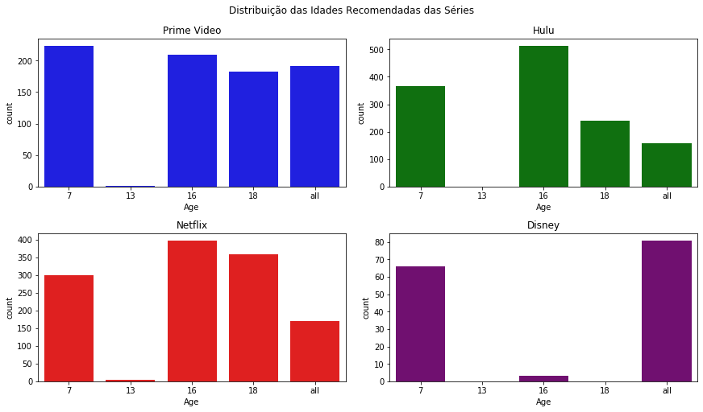

```python
fig,axs = plt.subplots(nrows = 2,ncols = 2,figsize=(12,7),constrained_layout=True)
fig.suptitle('Distribuição das Idades Recomendadas das Séries')
sns.countplot(x='Age',data=df_prime_series,ax=axs[0][0],order=order, color = 'blue')
axs[0][0].set_title('Prime Video')

sns.countplot(x='Age',data=df_hulu_series,ax=axs[0][1],order=order, color = 'green')
axs[0][1].set_title('Hulu')

sns.countplot(x='Age',data=df_netflix_series,ax=axs[1][0],order=order, color = 'red')
axs[1][0].set_title('Netflix')


sns.countplot(x='Age',data=df_disney_series,ax=axs[1][1],order=order, color = 'purple')
axs[1][1].set_title('Disney')


plt.show()
```

### 5.1.4. IMDb das plataformas

- Filmes

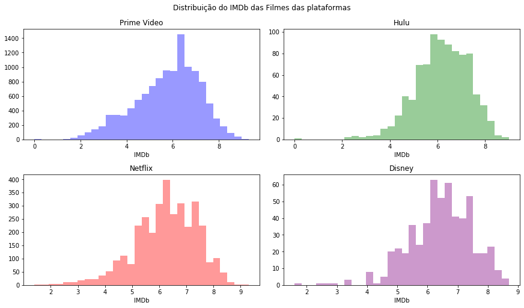

```python
fig,axes = plt.subplots(nrows = 2,ncols = 2,figsize=(12,7),constrained_layout=True)
fig.suptitle('Distribuição do IMDb das Filmes das plataformas')

sns.distplot(df_prime_movies['IMDb'], bins = 30, color="blue", kde=False,  ax=axes[0, 0])
axes[0][0].set_title('Prime Video')

sns.distplot(df_hulu_movies['IMDb'], bins = 30, color="green", kde=False,  ax=axes[0, 1])
axes[0][1].set_title('Hulu')

sns.distplot(df_netflix_movies['IMDb'], bins = 30, color="red", kde=False,  ax=axes[1, 0])
axes[1][0].set_title('Netflix')

sns.distplot(df_disney_movies['IMDb'], bins = 30, color="purple", kde=False,  ax=axes[1, 1])
axes[1][1].set_title('Disney')

plt.show()
```

- Séries

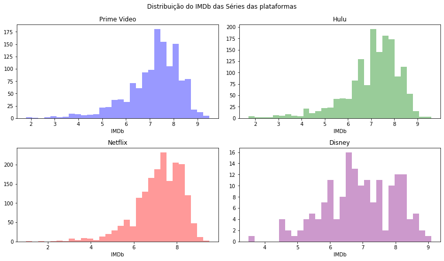

```python
fig,axes = plt.subplots(nrows = 2,ncols = 2,figsize=(12,7),constrained_layout=True)
fig.suptitle('Distribuição do IMDb das Séries das plataformas')

sns.distplot(df_prime_series['IMDb'], bins = 30, color="blue", kde=False,  ax=axes[0, 0])
axes[0][0].set_title('Prime Video')

sns.distplot(df_hulu_series['IMDb'], bins = 30, color="green", kde=False,  ax=axes[0, 1])
axes[0][1].set_title('Hulu')

sns.distplot(df_netflix_series['IMDb'], bins = 30, color="red", kde=False,  ax=axes[1, 0])
axes[1][0].set_title('Netflix')

sns.distplot(df_disney_series['IMDb'], bins = 30, color="purple", kde=False,  ax=axes[1, 1])
axes[1][1].set_title('Disney')

plt.show()
```

### 5.1.3. Ano de Lançamento dos Títulos(séries e filmes) por Plataforma

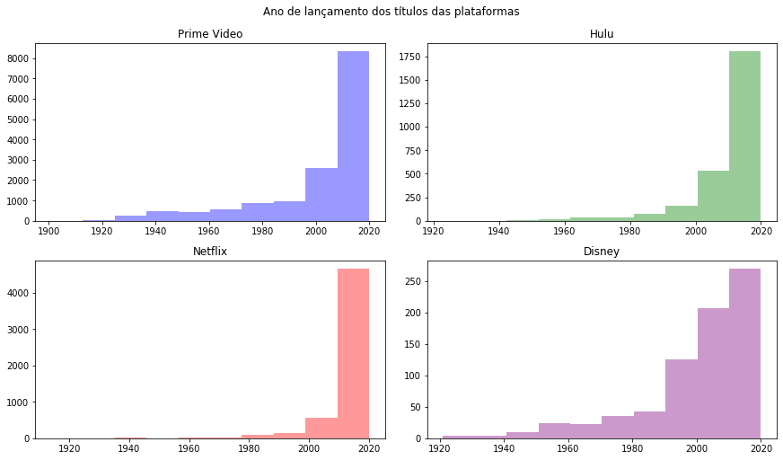

```python
dataYearPV = df_streaming[df_streaming['Prime Video'] == 1][['Year']]

dataYearNet = df_streaming[df_streaming['Netflix'] == 1][['Year']]

dataYearHulu = df_streaming[df_streaming['Hulu'] == 1][['Year']]

dataYearD = df_streaming[df_streaming['Disney+'] == 1][['Year']]

fig,axes = plt.subplots(nrows = 2,ncols = 2,figsize=(12,7),constrained_layout=True)
fig.suptitle('Ano de lançamento dos títulos das plataformas')

sns.distplot(dataYearPV,color="blue", bins = 10, kde=False, ax=axes[0, 0])
axes[0][0].set_title('Prime Video')


sns.distplot(dataYearHulu,color="green", bins = 10, kde=False, ax=axes[0, 1])
axes[0][1].set_title('Hulu')


sns.distplot(dataYearNet,color="red", bins = 10, kde=False, ax=axes[1, 0])
axes[1][0].set_title('Netflix')


sns.distplot(dataYearD,color="purple", bins = 10, kde=False, ax=axes[1, 1])
axes[1][1].set_title('Disney')


plt.show()
```

### 5.1.5. Principais Linguagens das plataformas

### Aqui, pegamos as 8 linguas mais presentes em cada plataforma. A escolha foi limitada a 8 para não gerar problemas na visualização

[figure not shown]

```python
lang_prime_movies = df_languages.iloc[df_prime_movies['ID']-1,1:].sum().sort_values(ascending=False).head(8)

lang_netflix_movies = df_languages.iloc[df_netflix_movies['ID']-1,1:].sum().sort_values(ascending=False).head(8)

lang_hulu_movies = df_languages.iloc[df_hulu_movies['ID']-1,1:].sum().sort_values(ascending=False).head(8)

lang_disney_movies = df_languages.iloc[df_disney_movies['ID']-1,1:].sum().sort_values(ascending=False).head(8)

fig,axes = plt.subplots(nrows = 2,ncols = 2,figsize=(14,7),constrained_layout=True)
fig.suptitle('As Linguas mais comuns de cada plataforma')

axes[0][0].bar(lang_prime_movies.index, list(lang_prime_movies))
axes[0][0].set_title('Prime Video')


axes[0][1].bar(lang_netflix_movies.index, list(lang_netflix_movies), color="green")
axes[0][1].set_title('Hulu')


axes[1][0].bar(lang_hulu_movies.index, list(lang_hulu_movies), color="red")
axes[1][0].set_title('Netflix')


axes[1][1].bar(lang_disney_movies.index, list(lang_disney_movies), color="purple")
axes[1][1].set_title('Disney')


plt.show()
```

### 5.1.6. Principais Gêneros de filmes das plataformas

### Aqui, também pegamos os 8 gêneros de filmes mais comuns

[figure not shown]

```python
gen_prime_movies = df_genres.iloc[df_prime_movies['ID']-1,3:].sum().sort_values(ascending=False).head(8)

gen_netflix_movies = df_genres.iloc[df_netflix_movies['ID']-1,3:].sum().sort_values(ascending=False).head(8)

gen_hulu_movies = df_genres.iloc[df_hulu_movies['ID']-1,3:].sum().sort_values(ascending=False).head(8)

gen_disney_movies = df_genres.iloc[df_disney_movies['ID']-1,3:].sum().sort_values(ascending=False).head(8)

fig,axes = plt.subplots(nrows = 2,ncols = 2,figsize=(14,8),constrained_layout=True)
fig.suptitle('As Linguas mais comuns de cada plataforma')

axes[0][0].bar(gen_prime_movies.index, list(gen_prime_movies))
axes[0][0].set_title('Prime Video')


axes[0][1].bar(gen_netflix_movies.index, list(gen_netflix_movies), color="green")
axes[0][1].set_title('Hulu')


axes[1][0].bar(gen_hulu_movies.index, list(gen_hulu_movies), color="red")
axes[1][0].set_title('Netflix')


axes[1][1].bar(gen_disney_movies.index, list(gen_disney_movies), color="purple")
axes[1][1].set_title('Disney')


plt.show()
```

### 5.1.6. Qual Plataforma tem mais filmes em Portugues

### Primeiramente tem-se de achar quais os idiomas em portugues(sinais brasileiros), para então poder filtar quais filmes estão na linguagem desejada.

```python
pt = []
for i in listLanguage:
    if(("Bra" in i) | ("Port" in i)):
        pt.append(i)
pt
```

```
['Brazilian Sign Language', 'Portuguese']
```

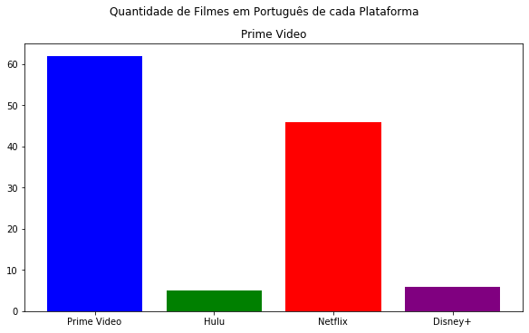

```python
# número de filmes em portugues no Prime Videos
pv_pt = df_languages[pt].iloc[df_prime_movies['ID']-1]
num_pv_pt = pv_pt[(pv_pt[pt[0]] == 1) | (pv_pt[pt[1]] == 1)].count()[0]
# número de filmes em portugues no Hulu
hulu_pt = df_languages[pt].iloc[df_hulu_movies['ID']-1]
num_hulu_pt = hulu_pt[(hulu_pt[pt[0]] == 1) | (hulu_pt[pt[1]] == 1)].count()[0]
# número de filmes em portugues na Netflix
net_pt = df_languages[pt].iloc[df_netflix_movies['ID']-1]
num_net_pt = net_pt[(net_pt[pt[0]] == 1) | (net_pt[pt[1]] == 1)].count()[0]
# número de filmes em portugues na Disney+
disney_pt = df_languages[pt].iloc[df_disney_movies['ID']-1]
num_disney_pt = disney_pt[(disney_pt[pt[0]] == 1) | (disney_pt[pt[1]] == 1)].count()[0]

fig,axes = plt.subplots(nrows = 1,ncols = 1,figsize=(8,5),constrained_layout=True)
fig.suptitle('Quantidade de Filmes em Português de cada Plataforma')

x = ['Prime Video', 'Hulu','Netflix','Disney+']
y = [num_pv_pt, num_hulu_pt, num_net_pt, num_disney_pt]
axes.bar(x, y, color = ['blue', 'green', 'red', 'purple'])
axes.set_title('Prime Video')
plt.show()
```

# 5.2 Gráficos Mapa Mundi

```python
country_imdb_mean = []

for i in listCountries:
    listaAlvo = list(df_countries[df_countries[i]==1]['ID'].iloc[:]-1)
    aux = df_movies.iloc[listaAlvo,:]
    country_imdb_mean.append(aux['IMDb'].mean())

num_Filmed = []
for i in listCountries:
    filmed = df_countries[i].sum()
    num_Filmed.append(filmed)

# fazendo uma série e arredondando para 1 casa decimal
country_imdb_mean = pd.Series(country_imdb_mean)
country_imdb_mean = country_imdb_mean.apply(lambda x: round(x,1))

aux = np.array([listCountries,country_imdb_mean,num_Filmed]).T
data_countries = pd.DataFrame(aux,columns='country Imdb num_Filmed'.split())

page_code = requests.get("https://countrycode.org/").content
soup = BeautifulSoup(page_code, 'html.parser')
tags = soup.find_all('tbody')
tr_tag = tags[0].find_all('tr')
name_code = []

for i in tr_tag:
    aux = i.find_all('td')
    name_code.append([aux[0].get_text(),aux[2].get_text().split('/')[1]])

code = ['']*len(data_countries['country'])


for i in range(len(name_code)):
    for j in range(len(listCountries)):
        if name_code[i][0] == listCountries[j]:
            code[j] = name_code[i][1]
        pass

data_countries['code'] =  pd.Series(code)
data_countries = data_countries[data_countries['Imdb'] != 'nan']
data_countries = data_countries[data_countries['code'] != '']
data_countries = data_countries.sort_values('Imdb',ascending = False)

imdb = list(data_countries.iloc[:,1])
imdb = pd.Series(imdb)
imdb = imdb.apply(lambda x: float(x))

filmed = list(data_countries.iloc[:,2])
filmed = pd.Series(filmed)
filmed = filmed.apply(lambda x: float(x))
filmed = filmed.apply(lambda x: np.log10(x))
```

```python
px.choropleth(data_countries,
              locationmode='country names',
              locations='country',
              color=imdb,
              hover_name='code',
              title='Média do IMDb por Pais',
              color_continuous_scale='Inferno')
```

[interactive chart not shown]

```python
px.choropleth(data_countries,
              locationmode='country names',
              locations='country',
              color= filmed,
              hover_name='code',
              title='Números, em escala log10, de filmes gravados em cada Pais',
              color_continuous_scale='Inferno')
```

[interactive chart not shown]

# 5.3 Filmes e Séries com melhor IMDb de cada plataforma

### 5.3.1. Melhores filmes de cada plataforma

- Prime Videos

```python
df_prime_movies.sort_values(by=['IMDb'],ascending=False)[['Title','Year','IMDb']].head(5)
```

|  | Title | Year | IMDb |
| --- | --- | --- | --- |
| 6566 | Square One | 2019 | 9.3 |
| 5110 | Love on a Leash | 2011 | 9.3 |
| 6837 | Steven Banks: Home Entertainment Center | 1989 | 9.3 |
| 7220 | Down, But Not Out! | 2015 | 9.3 |
| 7426 | Bounty | 2011 | 9.3 |

- Netflix

```python
df_netflix_movies.sort_values(by=['IMDb'],ascending=False)[['Title','Year','IMDb']].head(5)
```

|  | Title | Year | IMDb |
| --- | --- | --- | --- |
| 1292 | My Next Guest with David Letterman and Shah Ru... | 2019 | 9.3 |
| 947 | Natsamrat | 2016 | 9.1 |
| 4 | The Good, the Bad and the Ugly | 1966 | 8.8 |
| 0 | Inception | 2010 | 8.8 |
| 1214 | Bill Hicks: Relentless | 1992 | 8.7 |

- Hulu

```python
df_hulu_movies.sort_values(by=['IMDb'],ascending=False)[['Title','Year','IMDb']].head(5)
```

|  | Title | Year | IMDb |
| --- | --- | --- | --- |
| 3560 | The Dark Knight | 2008 | 9.0 |
| 3561 | GoodFellas | 1990 | 8.7 |
| 3562 | Parasite | 2019 | 8.6 |
| 3564 | The Green Mile | 1999 | 8.6 |
| 3566 | Grave of the Fireflies | 1988 | 8.5 |

- Disney+

```python
df_disney_movies.sort_values(by=['IMDb'],ascending=False)[['Title','Year','IMDb']].head(5)
```

|  | Title | Year | IMDb |
| --- | --- | --- | --- |
| 16213 | Star Wars: The Empire Strikes Back | 1980 | 8.7 |
| 16212 | Star Wars: A New Hope | 1977 | 8.6 |
| 16441 | Newsies: The Broadway Musical | 2017 | 8.5 |
| 16214 | The Lion King | 1994 | 8.5 |
| 16221 | Coco | 2017 | 8.4 |

### 5.3.2. Melhores séries de cada plataforma

- Prime Video

```python
df_prime_series.sort_values(by=['IMDb'],ascending=False)[['Title','Year','IMDb']].head(5)
```

|  | Title | Year | IMDb |
| --- | --- | --- | --- |
| 3747 | Malgudi Days | 1987 | 9.5 |
| 2365 | The Joy of Painting | 1983 | 9.4 |
| 3567 | Band of Brothers | 2001 | 9.4 |
| 4128 | Green Paradise | 2011 | 9.3 |
| 3566 | The Wire | 2002 | 9.3 |

- Netflix

```python
df_netflix_series.sort_values(by=['IMDb'],ascending=False)[['Title','Year','IMDb']].head(5)
```

|  | Title | Year | IMDb |
| --- | --- | --- | --- |
| 0 | Breaking Bad | 2008 | 9.5 |
| 325 | Ramayan | 1987 | 9.3 |
| 91 | Our Planet | 2019 | 9.3 |
| 282 | Yeh Meri Family | 2018 | 9.2 |
| 9 | Avatar: The Last Airbender | 2005 | 9.2 |

- Hulu

```python
df_hulu_series.sort_values(by=['IMDb'],ascending=False)[['Title','Year','IMDb']].head(5)
```

|  | Title | Year | IMDb |
| --- | --- | --- | --- |
| 3023 | Destiny | 2014 | 9.6 |
| 3177 | Hungry Henry | 2014 | 9.5 |
| 2365 | The Joy of Painting | 1983 | 9.4 |
| 1931 | Rick and Morty | 2013 | 9.2 |
| 2236 | Leah Remini: Scientology and the Aftermath | 2016 | 9.1 |

- Disney+

```python
df_disney_series.sort_values(by=['IMDb'],ascending=False)[['Title','Year','IMDb']].head(5)
```

|  | Title | Year | IMDb |
| --- | --- | --- | --- |
| 5465 | The Imagineering Story | 2019 | 9.1 |
| 1948 | Gravity Falls | 2012 | 8.9 |
| 5461 | One Strange Rock | 2018 | 8.8 |
| 1935 | The Simpsons | 1989 | 8.7 |
| 5455 | The Mandalorian | 2019 | 8.7 |